# Data Mining I project - Draft report

## Profiling (ASSESS)

The profiling will encompass two main steps. Firstly, we’ll profile the two segmentations separately. Secondly, we’ll consolidate both segmentations to have a global view of the customers and decide on the Marketing strategy.

### Value segmentation

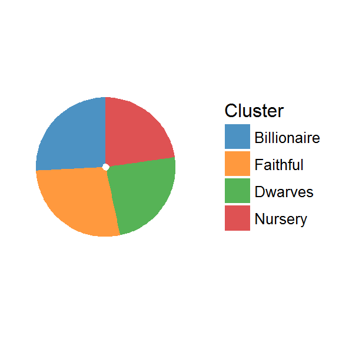

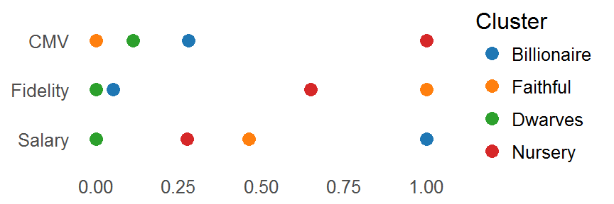

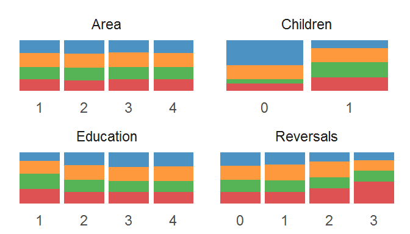

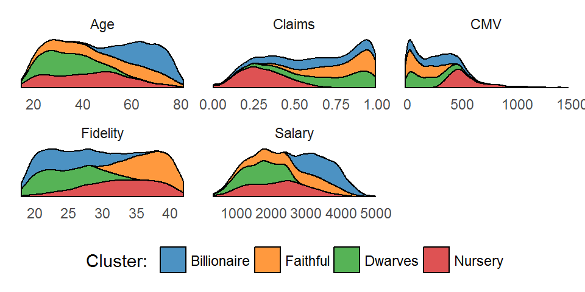

### Product segmentation

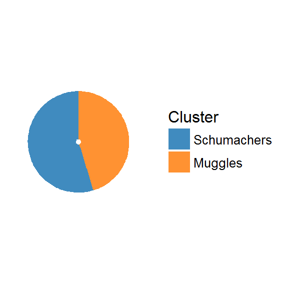

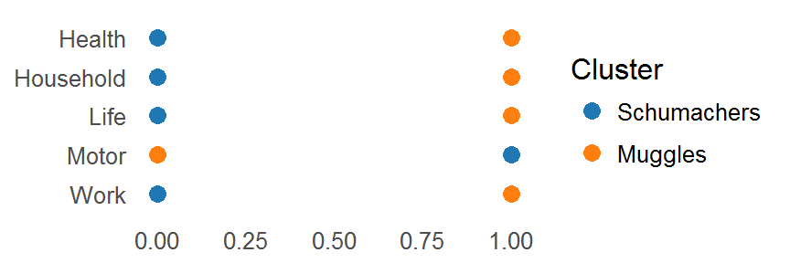

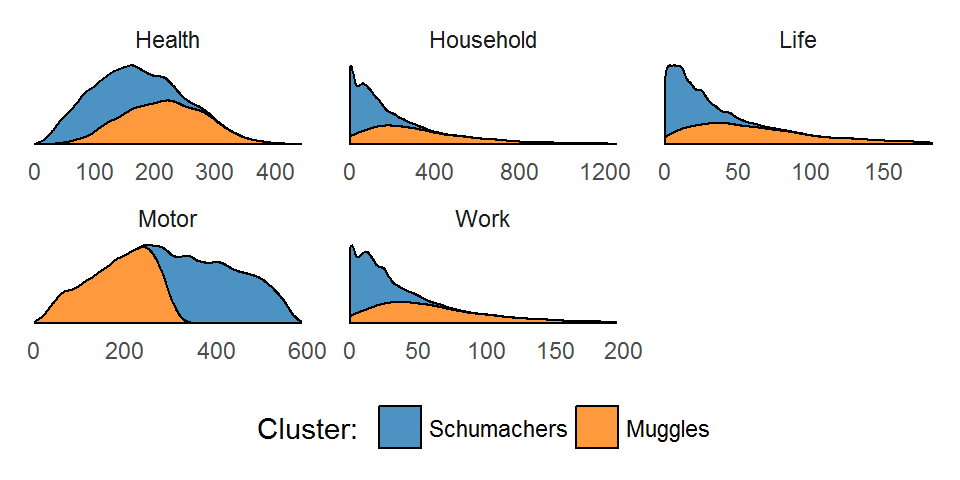

### Consolidated segmentation

When we consolidate the two segmentation, we get 8 clusters:

| value_cluster | product_cluster | number | freq | full_cluster | CMV | Salary | Fidelity | Household | Health | Life | Motor | Work |
| --- | --- | --- | --- | --- | --- | --- | --- | --- | --- | --- | --- | --- |
| Nursery | Muggles | 1015 | 0.0985820 | Nursery Muggles | 539.95743 | 2182.164 | 32.53171 | 329.63775 | 214.8857 | 61.72158 | 185.1436 | 61.83922 |
| Dwarves | Schumachers | 1130 | 0.1097514 | Dwarves Schumachers | 114.05033 | 1675.434 | 24.79577 | 88.39709 | 132.2176 | 17.16481 | 405.8858 | 17.28489 |
| Billionaire | Muggles | 1229 | 0.1193667 | Billionaire Muggles | 195.19015 | 3513.246 | 25.40324 | 329.63775 | 214.8857 | 61.72158 | 185.1436 | 61.83922 |
| Faithful | Muggles | 1303 | 0.1265540 | Faithful Muggles | 60.79571 | 2526.169 | 36.71732 | 329.63775 | 214.8857 | 61.72158 | 185.1436 | 61.83922 |
| Dwarves | Muggles | 1330 | 0.1291764 | Dwarves Muggles | 114.05033 | 1675.434 | 24.79577 | 329.63775 | 214.8857 | 61.72158 | 185.1436 | 61.83922 |
| Nursery | Schumachers | 1331 | 0.1292735 | Nursery Schumachers | 539.95743 | 2182.164 | 32.53171 | 88.39709 | 132.2176 | 17.16481 | 405.8858 | 17.28489 |
| Billionaire | Schumachers | 1425 | 0.1384033 | Billionaire Schumachers | 195.19015 | 3513.246 | 25.40324 | 88.39709 | 132.2176 | 17.16481 | 405.8858 | 17.28489 |
| Faithful | Schumachers | 1533 | 0.1488928 | Faithful Schumachers | 60.79571 | 2526.169 | 36.71732 | 88.39709 | 132.2176 | 17.16481 | 405.8858 | 17.28489 |

Although customers are almost uniformly distributed among all clusters, we considered that 8 is too large a number of clusters for creating different Marketing strategies. Therefore, we will aggregate the 2 clusters with the lowest number of customers in order to have only 6 clusters.

To do it, we chose the value sgmentation as the main one and thus we change the product segmentation when we need to reduce the number of cluster.

After applying these changes, the final clusters have the following ditributions and pie chart:

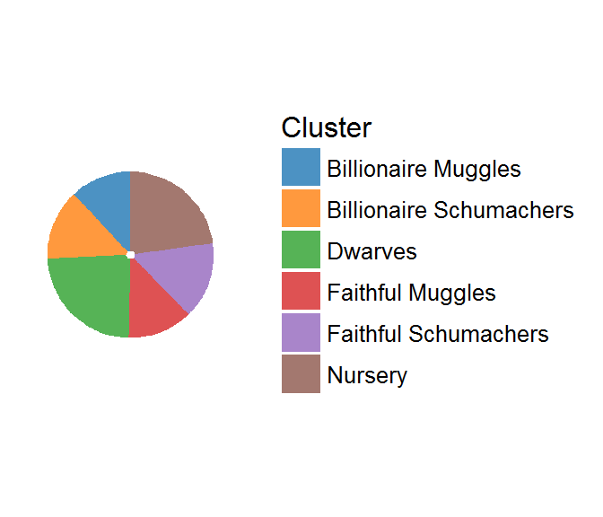

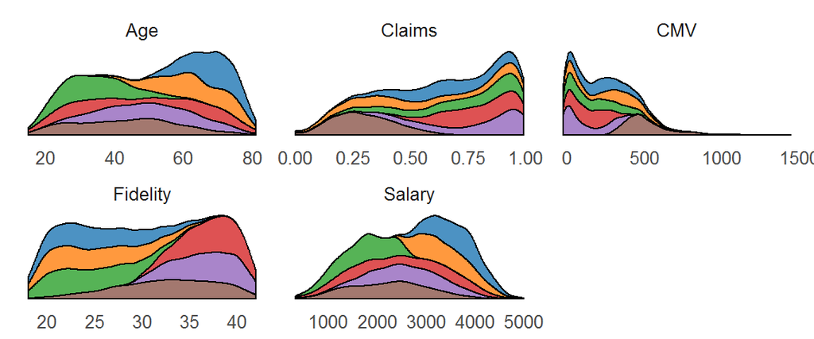

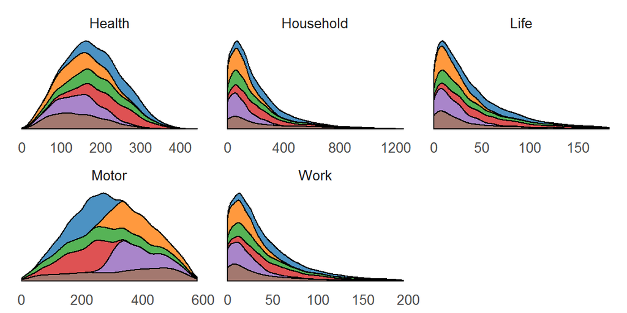

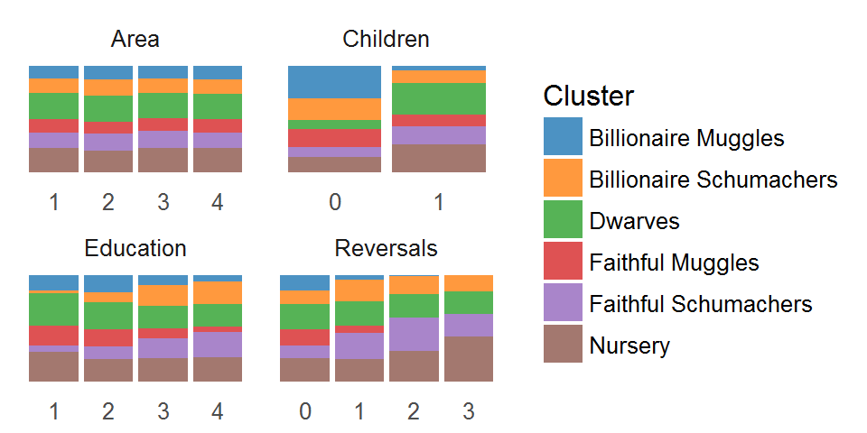